# Independent t-test

Last edited: 16 April 2022

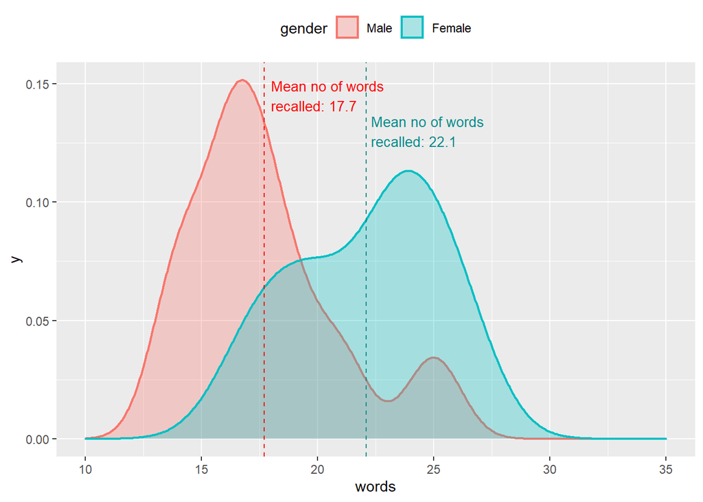

# 1 Aim

The independent *t* test is used for testing the difference between means of two independent groups. It is particularly useful when the research question requires the comparison of variables (measured at least at the ordinal level) obtained from two independent samples.

# 2 Assumptions

- Independence - each sample has been randomly selected from the population it represents.
- Normality - the distribution of data in the underlying population from which each of hte samples is derived is normal.
- Homogeneity of variance - the distribution of the dependent variable for one of the groups being compared has the same variance as the distribution for the other group being compared.

# 3 Data

```r
skimr::skim_tee(memory_ability)
```

```
-- Data Summary ------------------------
                           Values
Name                       data
Number of rows             20
Number of columns          2
_______________________
Column type frequency:
  factor                   1
  numeric                  1
________________________
Group variables            None

-- Variable type: factor -------------------------------------------------------
# A tibble: 1 x 6
  skim_variable n_missing complete_rate ordered n_unique top_counts
* <chr>             <int>         <dbl> <lgl>      <int> <chr>
1 gender                0             1 FALSE          2 Mal: 10, Fem: 10

-- Variable type: numeric ------------------------------------------------------
# A tibble: 1 x 11
  skim_variable n_missing complete_rate  mean    sd    p0   p25   p50   p75
* <chr>             <int>         <dbl> <dbl> <dbl> <dbl> <dbl> <dbl> <dbl>
1 words                 0             1  19.9  3.89    14    17  19.5  23.2
   p100 hist
* <dbl> <chr>
1    26 ▆▇▆▃▇
```

# 4 Testing assumptions

## 4.1 Independence

During data collection, ensure that the observation in one group are independent of the observations of the other group.

## 4.2 Normality test

For a start, a qqplot or the “quantile-quantile” plot can be used to quickly assess whether or not the data or a variable follows a normal distribution. If normally distributed, the data points will lie on the straight diagonal line. For the qqplot below, most of the points lie on the diagonal line but with some deviations along each of the tails.

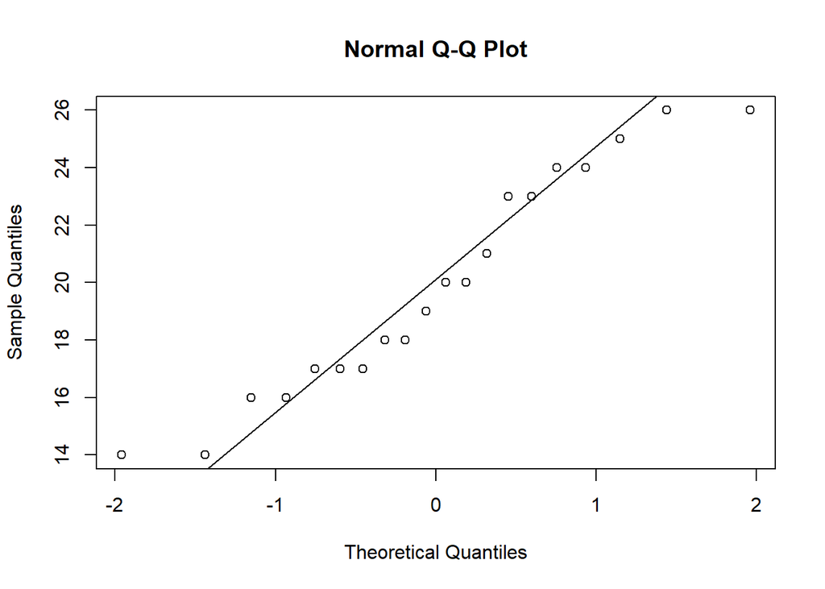

```r
qqnorm(memory_ability$words)
qqline(memory_ability$words)
```

Whereas the Shapiro-Wilk statistic tests for normality. If the significance level are greater than 0.05, then normality is assumed. The Shapiro-Wilk test is recommended when sample size is small (~ <50). Result of the Shapiro-Wilk test below, the computed significance level is 0.201, implying normality can be assumed.

```r
shapiro.test(memory_ability$words)
```

```
    Shapiro-Wilk normality test

data:  memory_ability$words
W = 0.93591, p-value = 0.2005
```

## 4.3 Homogeneity of variance

The Levene’s test can be used to check the assumption on the homogeneity of variance. The Levene’s tes for equality of variance tests the hypothesis that the two population variances are equal.

The results below shows that the Levene statistic is *F=0.087* and the corresponding level of significance is large (i.e., *p>0.05*). Hence, the assumption of homogeneity of variance has not been violated, and the equal variances assumed implying *t* test statistic can be used for evaluating the null hypothesis of equality of means.

```r
car::leveneTest(words ~ gender, data = memory_ability, center = "mean")
```

```
Levene's Test for Homogeneity of Variance (center = "mean")
      Df F value Pr(>F)
group  1  0.0869 0.7715
      18
```

# 5 Results and interpretation

The result from the *t* test indicate that there is a significant differenc between the male and female samples in the number of words correctly recalled, *t(df=18)=-3.02, p<0.01*. The mean values indicate that females correctly recalled significantly more words (M=22.10) than males(M=17.70).

The confidence interval information shows that the null hypothesis value (i.e., zero) does not fall within the interval. Therefore the null hypothesis of equality of means can be rejected.

```r
ind_ttest <-
t.test(words ~ gender, data = memory_ability, alternative = "two.sided")

ind_ttest
```

```
    Welch Two Sample t-test

data:  words by gender
t = -3.0203, df = 17.958, p-value = 0.007367
alternative hypothesis: true difference in means between group Male and group Female is not equal to 0
95 percent confidence interval:
 -7.461101 -1.338899
sample estimates:
  mean in group Male mean in group Female
                17.7                 22.1
```

$$\eta^2 = \frac{t^2}{t^2 + df}$$

```r
ind_ttest$statistic^2 / (ind_ttest$statistic^2 + ind_ttest$parameter)
```

```
        t
0.3368622
```

# 6 Manual computation

The t statistic for the t test for independent sample is given by:

$$t = \frac{\bar{X_1} - \bar{X_2}}{\sqrt{\frac{s_1^2}{n_1} + \frac{s_2^2}{n_1}}}$$
where $\bar{X}$ is the mean value for each group, $S^2$ is the sample variance, and $n$ number of observation in each group.

```r
# X1 - mean words recalled by male
mean_male <-
memory_ability %>% filter(gender == "Male") %>% summarise(m_words = mean(words)) %>% pull()

# X2 - mean words recalled by female
mean_female <-
memory_ability %>% filter(gender == "Female") %>% summarise(m_words = mean(words)) %>% pull()

# s1 - variance of words recalled by male
variance_male <-
memory_ability %>% filter(gender == "Male") %>% summarise(m_words = var(words)) %>% pull()

# s2 - variance of words recalled by female
variance_female <-
memory_ability %>% filter(gender == "Female") %>% summarise(m_words = var(words)) %>% pull()

# no of male
n_male <-
memory_ability %>% filter(gender == "Male") %>% count() %>% pull()

# no of female
n_female <-
memory_ability %>% filter(gender == "Female") %>% count() %>% pull()
```

```r
# Computing the t statistic
t_stat <-
(mean_male - mean_female) / sqrt((variance_male/n_male) + (variance_female/ n_female))

t_stat
```

```
[1] -3.02035
```

```r
# Deriving the two-tailed p-value
pt(q = t_stat, df = 18) * 2
```

```
[1] 0.007352521
```

### References

Ho, Robert (2014).Handbook of Univariate and Multivariate Data Analysis with IBM SPSS (2nd edition). Chapman & Hall/CRC, Taylor & Francis Group.

Sheskin, David J. (2011). Handbook of Parametric and Nonparametric Statistical Procedures (5th edition). Chapman & Hall/CRC, Taylor & Francis Group.